# Solution_case-study_logisticRegression

### Context

To minimize loss from the bank’s perspective, the bank needs a decision rule regarding whom to approve the loan and whom not to. An applicant’s demographic and socio-economic profiles are considered by loan managers before a decision is taken regarding his/her loan application. In this dataset, each entry represents a person who takes credit from a bank. Each person is classified as a good or bad credit risk according to the set of attributes.

### Objective

The objective is to build a predictive model on this data to help the bank decide on whether to approve a loan to a prospective applicant.

### Dataset

- Age (Numeric: Age in years)
- Sex (Categories: male, female)
- Job (Categories: unskilled and non-resident, unskilled and resident, skilled, highly skilled)
- Housing (Categories: own, rent, or free)
- Saving accounts (Categories: little, moderate, quite rich, rich)
- Checking account (Categories: little, moderate, rich)
- Credit amount (Numeric: Amount of credit in DM - Deutsche Mark)
- Duration (Numeric: Duration for which the credit is given in months)
- Purpose (Categories: car, furniture/equipment,radio/TV, domestic appliances, repairs, education, business, vacation/others)
- Risk (0 - Person is not at risk, 1 - Person is at risk(defaulter))

## Let's start by importing necessary libraries

```python
## Load and overview the dataset# this will help in making the Python code more structured automatically (good coding practice)
%load_ext nb_black

import warnings

warnings.filterwarnings("ignore")

# Libraries to help with reading and manipulating data

import pandas as pd
import numpy as np

# Library to split data
from sklearn.model_selection import train_test_split

# libaries to help with data visualization
import matplotlib.pyplot as plt
import seaborn as sns

# Removes the limit for the number of displayed columns
pd.set_option("display.max_columns", None)
# Sets the limit for the number of displayed rows
pd.set_option("display.max_rows", 200)


# To build model for prediction

from sklearn.linear_model import LogisticRegression

# To get diferent metric scores
# To get diferent metric scores

from sklearn.metrics import (
    f1_score,
    accuracy_score,
    recall_score,
    precision_score,
    confusion_matrix,
    roc_auc_score,
    plot_confusion_matrix,
    precision_recall_curve,
    roc_curve,
)
from sklearn.preprocessing import (
    binarize,
)  # to get prediction column w.r.t given threshold
from mlxtend.feature_selection import (
    SequentialFeatureSelector as SFS,
)  # for feature selection
from sklearn.model_selection import GridSearchCV  # for hyperparameter tuning
```

## Load and overview the dataset

```python
# Loading the dataset - sheet_name parameter is used if there are multiple tabs in the excel file.
data = pd.read_csv("German_Credit.csv")
```

```python
data.head()
```

|  | Age | Sex | Job | Housing | Saving accounts | Checking account | Credit amount | Duration | Risk | Purpose |
| --- | --- | --- | --- | --- | --- | --- | --- | --- | --- | --- |
| 0 | 67 | male | skilled | own | little | little | 1169 | 6 | 0 | radio/TV |
| 1 | 22 | female | skilled | own | little | moderate | 5951 | 48 | 1 | radio/TV |
| 2 | 49 | male | unskilled_and_non-resident | own | little | little | 2096 | 12 | 0 | education |
| 3 | 45 | male | skilled | free | little | little | 7882 | 42 | 0 | furniture/equipment |
| 4 | 53 | male | skilled | free | little | little | 4870 | 24 | 1 | car |

### Understand the shape of the dataset.

```python
data.shape
```

```
(1000, 10)
```

### Check the data types of the columns in the dataset.

```python
data.info()
```

```
<class 'pandas.core.frame.DataFrame'>
RangeIndex: 1000 entries, 0 to 999
Data columns (total 10 columns):
 #   Column            Non-Null Count  Dtype
---  ------            --------------  -----
 0   Age               1000 non-null   int64
 1   Sex               1000 non-null   object
 2   Job               1000 non-null   object
 3   Housing           1000 non-null   object
 4   Saving accounts   1000 non-null   object
 5   Checking account  1000 non-null   object
 6   Credit amount     1000 non-null   int64
 7   Duration          1000 non-null   int64
 8   Risk              1000 non-null   int64
 9   Purpose           1000 non-null   object
dtypes: int64(4), object(6)
memory usage: 78.2+ KB
```

- There are total 10 columns and 1,000 observations in the dataset
- We have only three continuous variables - Age, Credit Amount, and Duration.
- All other variables are categorical.
- There no missing values in the dataset.

```python
data.nunique()
```

```
Age                  53
Sex                   2
Job                   3
Housing               3
Saving accounts       4
Checking account      3
Credit amount       921
Duration             33
Risk                  2
Purpose               8
dtype: int64
```

### Summary of the data

```python
data[["Age", "Credit amount", "Duration"]].describe().T
```

|  | count | mean | std | min | 25% | 50% | 75% | max |
| --- | --- | --- | --- | --- | --- | --- | --- | --- |
| Age | 1000.0 | 35.546 | 11.375469 | 19.0 | 27.0 | 33.0 | 42.00 | 75.0 |
| Credit amount | 1000.0 | 3271.258 | 2822.736876 | 250.0 | 1365.5 | 2319.5 | 3972.25 | 18424.0 |
| Duration | 1000.0 | 20.903 | 12.058814 | 4.0 | 12.0 | 18.0 | 24.00 | 72.0 |

**Observations**

- Mean value for the age column is approx 35 and the median is 33. This shows that majority of the customers are near to 35 years of age. It is right skewed also.
- Mean amount of credit is approx 3,271 but it has a wide range with values from 250 to 18,424. And it is also right skewed.
- Mean duration for which the credit is given is approx 21 months.

```python
# Making a list of all catrgorical variables
cat_col = [
    "Sex",
    "Job",
    "Housing",
    "Saving accounts",
    "Checking account",
    "Purpose",
    "Risk",
]

# Printing number of count of each unique value in each column
for column in cat_col:
    print(data[column].value_counts())
    print("-" * 40)
```

```
male      690
female    310
Name: Sex, dtype: int64
----------------------------------------
skilled                       630
unskilled_and_non-resident    222
highly skilled                148
Name: Job, dtype: int64
----------------------------------------
own     713
rent    179
free    108
Name: Housing, dtype: int64
----------------------------------------
little        786
moderate      103
quite rich     63
rich           48
Name: Saving accounts, dtype: int64
----------------------------------------
moderate    472
little      465
rich         63
Name: Checking account, dtype: int64
----------------------------------------
car                    337
radio/TV               280
furniture/equipment    181
business                97
education               59
repairs                 22
domestic appliances     12
vacation/others         12
Name: Purpose, dtype: int64
----------------------------------------
0    700
1    300
Name: Risk, dtype: int64
----------------------------------------
```

- We have more male customers as compared to female customers
- Customers with skilled job, customers with owning house, customers with little saving accounts, customers with moderate checking account and customers with the purpose of buying car are in majority.
- We can see that the distribution of classes in the target variable is imbalanced i.e., only 30% observations with defaulters.
- Most of the customers are not at risk.

## Univariate analysis

### Continuous variables

```python
def histogram_boxplot(data, feature, figsize=(12, 7), kde=False, bins=None):
    """
    Boxplot and histogram combined

    data: dataframe
    feature: dataframe column
    figsize: size of figure (default (12,7))
    kde: whether to show the density curve (default False)
    bins: number of bins for histogram (default None)
    """
    f2, (ax_box2, ax_hist2) = plt.subplots(
        nrows=2,  # Number of rows of the subplot grid= 2
        sharex=True,  # x-axis will be shared among all subplots
        gridspec_kw={"height_ratios": (0.25, 0.75)},
        figsize=figsize,
    )  # creating the 2 subplots
    sns.boxplot(
        data=data, x=feature, ax=ax_box2, showmeans=True, color="violet"
    )  # boxplot will be created and a star will indicate the mean value of the column
    sns.histplot(
        data=data, x=feature, kde=kde, ax=ax_hist2, bins=bins, palette="winter"
    ) if bins else sns.histplot(
        data=data, x=feature, kde=kde, ax=ax_hist2
    )  # For histogram
    ax_hist2.axvline(
        data[feature].mean(), color="green", linestyle="--"
    )  # Add mean to the histogram
    ax_hist2.axvline(
        data[feature].median(), color="black", linestyle="-"
    )  # Add median to the histogram
```

### Observation on Age

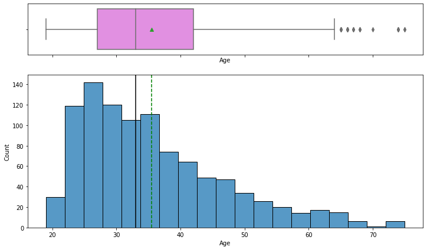

```python
histogram_boxplot(data, "Age")
```

- The distribution of age is right-skewed
- The boxplot shows that there are outliers at the right end
- We will not treat these outliers as they represent the real market trend

### Observation on Credit Amount

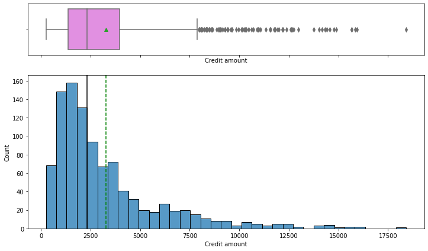

```python
histogram_boxplot(data, "Credit amount")
```

- The distribution of the credit amount is also right-skewed
- The boxplot shows that there are outliers at the right end
- Again we will not treat these outliers as they represent the real market trend

### Observations on Duration

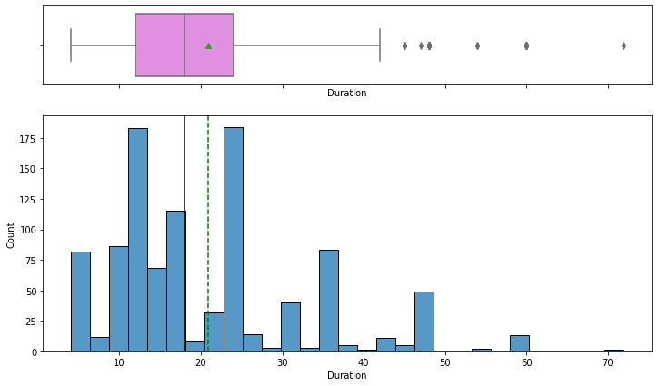

```python
histogram_boxplot(data, "Duration")
```

- The distribution of the duration for which the credit is given is right-skewed
- The boxplot shows that there are outliers at the right end
- We will not treat these outliers as they represent the real market trend

### Categorical variables

```python
def countPlot(feature):
    val_count = (data[feature].value_counts() / data[feature].count()) * 100
    for i in range(len(val_count)):
        print(val_count.index[i], ":", np.round(val_count[i], 2), "%")
    sns.set({"figure.figsize": (10, 5)})
    sns.countplot(x=feature, data=data)
    plt.xticks(rotation=90, fontsize=15)
```

### Observations on Sex of Customers

```
male : 69.0 %
female : 31.0 %
```

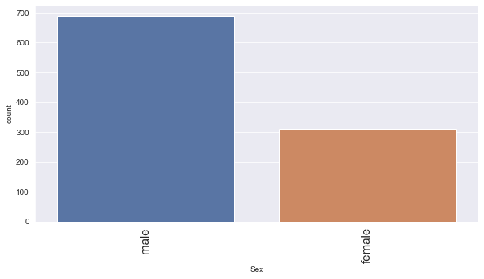

```python
countPlot("Sex")
```

- There are 69% male customers and 31% female customers

### Observations on Job

```
skilled : 63.0 %
unskilled_and_non-resident : 22.2 %
highly skilled : 14.8 %
```

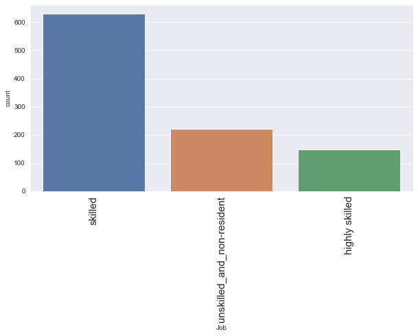

```python
countPlot("Job")
```

- Majority of the customers i.e. 63% fall into the skilled category.
- There are only approx 15% customers that lie in highly skilled category which makes sense as these may be the persons with high education or highly experienced.
- There are very few observations, approx 22% unskilled

### Observations on Housing

```
own : 71.3 %
rent : 17.9 %
free : 10.8 %
```

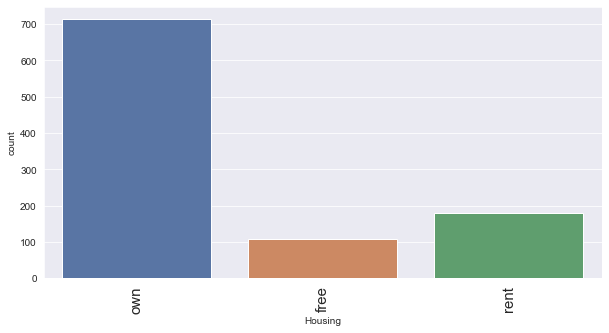

```python
countPlot("Housing")
```

- Major of the customers, approx 71%, who take credit have their own house
- Approx 18% customers are living in a rented house
- There are only 11% customers who have free housing. These are the customers who live in a house given by their company or organization

### Observations on Saving accounts

```
little : 78.6 %
moderate : 10.3 %
quite rich : 6.3 %
rich : 4.8 %
```

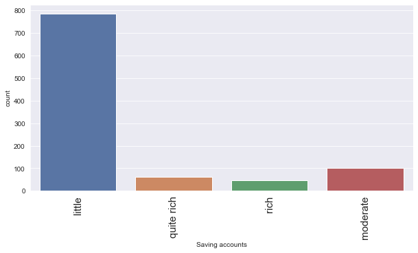

```python
countPlot("Saving accounts")
```

- Approx 89% customers who take credit have a little or moderate amount in their savings account. This makes sense as these customers would need credit more than the other categories.
- Approx 11% customers who take credit are in the rich category based on their balance in the savings account.

### Observations on Checking account

```
moderate : 47.2 %
little : 46.5 %
rich : 6.3 %
```

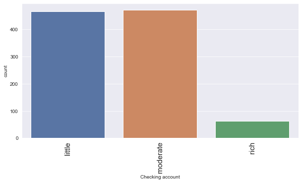

```python
countPlot("Checking account")
```

- Approx 94% customers who take credit have a little or moderate amount in their checking account. This makes sense as these customers would need credit more than the other categories.
- Approx 6% customers who take credit are in the rich category based on their balance in the checking account.

### Observations on Purpose

```
car : 33.7 %
radio/TV : 28.0 %
furniture/equipment : 18.1 %
business : 9.7 %
education : 5.9 %
repairs : 2.2 %
domestic appliances : 1.2 %
vacation/others : 1.2 %
```

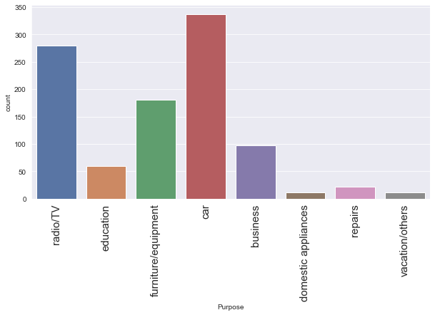

```python
countPlot("Purpose")
```

- The plot shows that most customers take credit for luxury items like car, radio or furniture/equipment, domestic appliances.
- Approximately just 16% customers take credit for business or education

### Observations on Risk

```
0 : 70.0 %
1 : 30.0 %
```

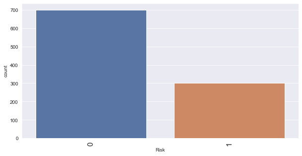

```python
countPlot("Risk")
```

- As mentioned earlier, the class distribution in the target variable is imbalanced.
- We have 70% observations for non-defaulters and 30% observations for defaulters.

**Insights**

- class distribution in the target variable is imbalanced
- 70% observations for non-defaulters and 30% observations for defaulters
- The distribution of age is right-skewed
- The distribution of the credit amount is also right-skewed
- The distribution of the duration for which the credit is given is right-skewed
- There are 69% male customers and 31% female customers
- 63% skilled category, 22% unskilled, 15% highly skilled category
- 71% own house, 18% rented house, 11% free housing
- 89% customers little or moderate savings account, 11% customers rich savings account
- 94% customers little or moderate checking account, 6% customers rich checking account
- most customers take credit for luxury items like car, radio or furniture/equipment and domestic appliances, 16% customers take credit for business or education

## Bivariate Analysis

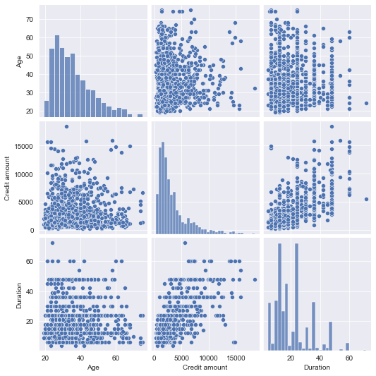

```python
sns.pairplot(data[['Age','Credit amount','Duration']])
```

```python
data[["Age", "Credit amount", "Duration"]].corr()
```

|  | Age | Credit amount | Duration |
| --- | --- | --- | --- |
| Age | 1.000000 | 0.032716 | -0.036136 |
| Credit amount | 0.032716 | 1.000000 | 0.624984 |
| Duration | -0.036136 | 0.624984 | 1.000000 |

### categorical vs continuous variables

```python
def cat_VS_con(x, y):

    sns.set({"figure.figsize": (16, 18)})

    plt.subplot(3, 2, 1)
    sns.swarmplot(data=data, x=x, y=y)

    plt.subplot(3, 2, 2)
    sns.stripplot(data=data, x=x, y=y)

    plt.subplot(3, 2, 3)
    sns.barplot(data=data, x=x, y=y)

    plt.subplot(3, 2, 4)
    sns.pointplot(data=data, x=x, y=y)

    plt.subplot(3, 2, 5)
    sns.boxplot(data=data, x=x, y=y)

    plt.subplot(3, 2, 6)
    sns.boxplot(data=data, x=x, y=y, showfliers=False)
```

### Risk vs Age

```python
# data[data["Risk"] == 0].Age.mean()
```

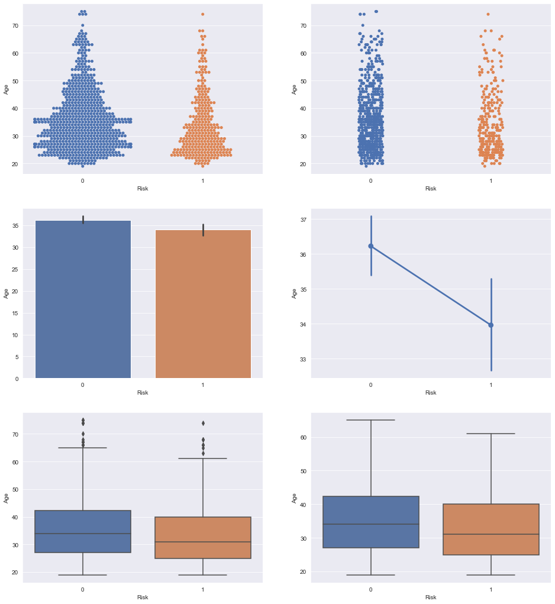

```python
cat_VS_con("Risk", "Age")
```

- We can see that the median age of defaulters is less than the median age of non-defaulters.
- This shows that younger customers are more likely to default as compare to elder customers
- There are outliers in boxplots of both class distributions

### Risk vs Credit amount

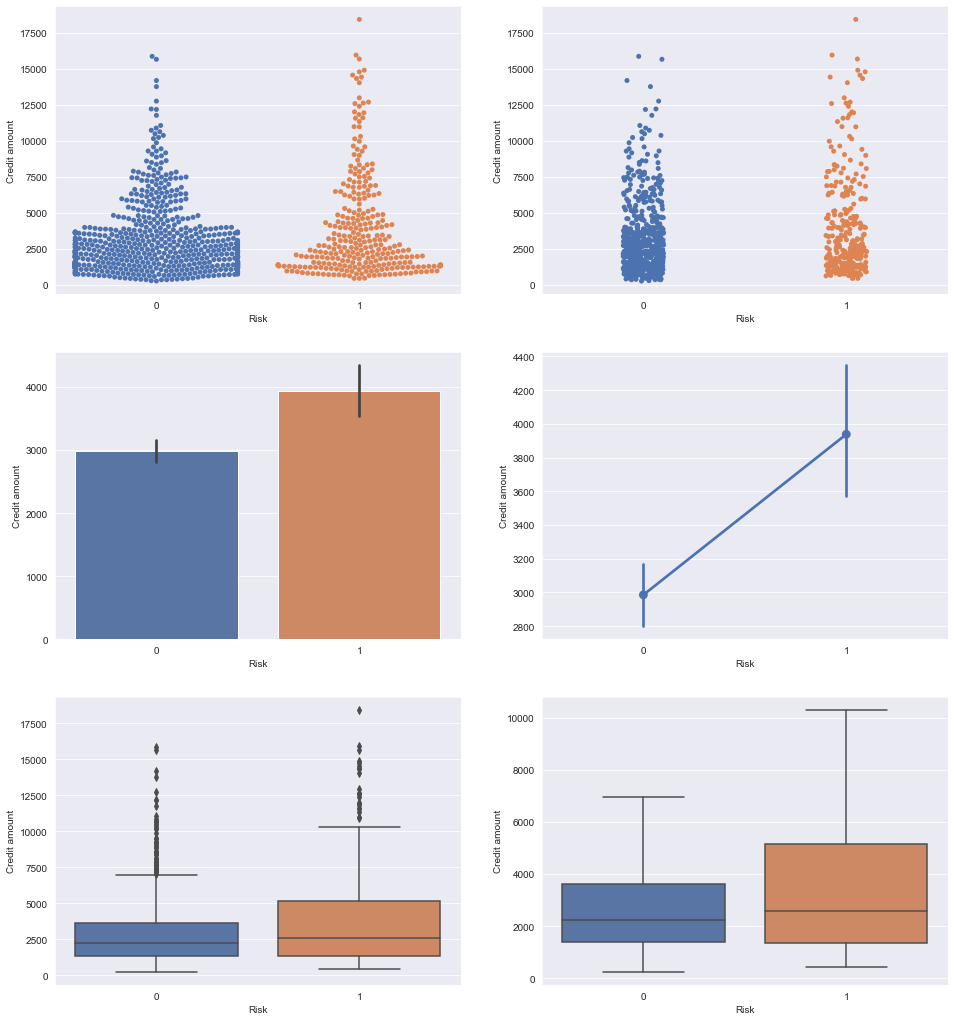

```python
cat_VS_con("Risk", "Credit amount")
```

```python
data[data["Risk"] == 0]["Credit amount"].mean()
```

```
2985.457142857143
```

```python
data[data["Risk"] == 1]["Credit amount"].mean()
```

```
3938.1266666666666
```

- We can see that the third quartile amount of defaulters is much more than the third quartile amount of non-defaulters.
- This shows that customers with high credit amount are more likely to default compare to customers with low credit amount.
- There are outliers in boxplots of both class distributions

### Risk vs Duration

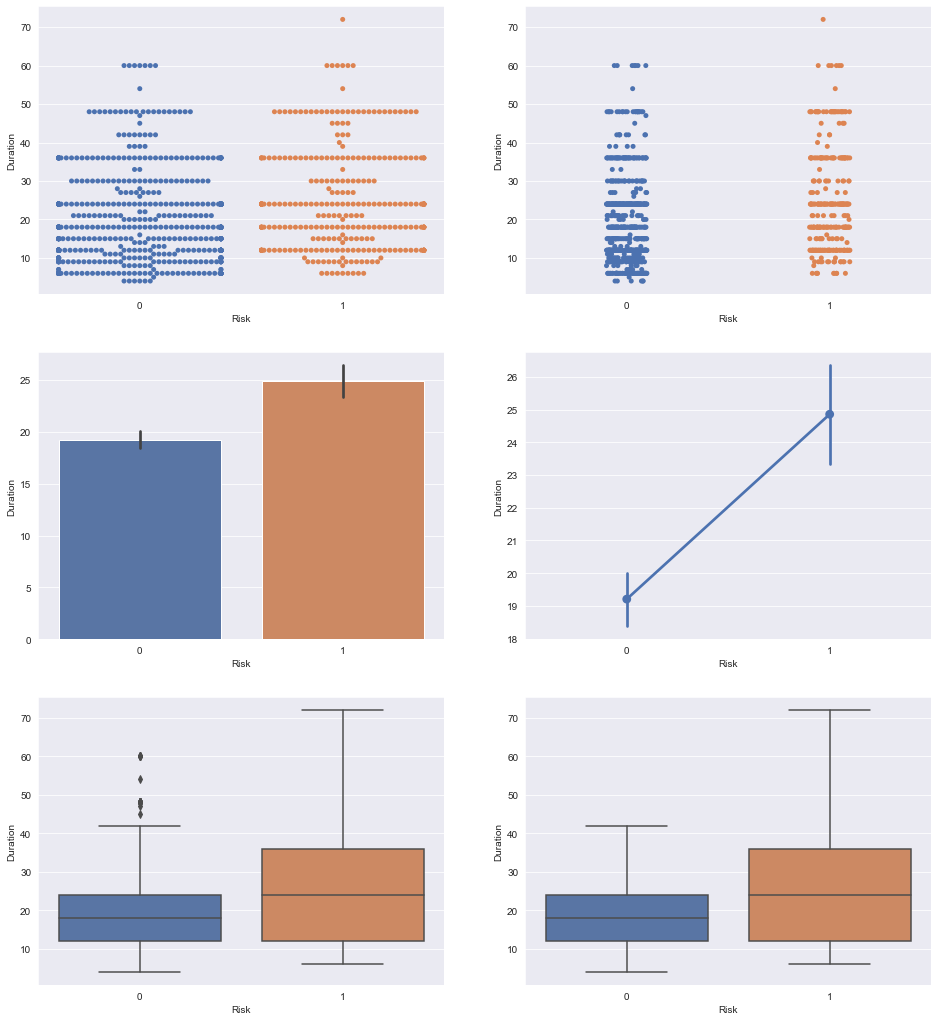

```python
cat_VS_con("Risk", "Duration")
```

- We can see that the second and third quartiles of duration of defaulters is much more than the second and third quartiles duration of non-defaulters.
- This shows that customers with high duration are more likely to default compare to customers with low duration.

### categorical vs categorical variables

```python
# percentage of default(1) or not default(0) w.r.t each category
def percentage_0_1(feature):
    val_count = data[feature].value_counts()

    for i in range(len(val_count)):

        print(
            "-----------Out of all ",
            val_count.index[i],
            " (",
            val_count[i],
            ")-----------",
        )

        d1 = len(
            data[(data[val_count.name] == val_count.index[i]) & (data["Risk"] == 1)]
        )
        not_d1 = len(
            data[(data[val_count.name] == val_count.index[i]) & (data["Risk"] == 0)]
        )

        d2 = np.round((d1 / val_count[i]) * 100, 2)
        not_d2 = np.round((not_d1 / val_count[i]) * 100, 2)
        print(d2, "% ", val_count.index[i], " -----------default")
        print(not_d2, "% ", val_count.index[i], " -----------not default\n")
```

### Risk vs Sex

```python
# dff1 = pd.crosstab(data["Sex"], data["Risk"], rownames=[""])
# dff1["not_default(%)"] = dff1[0] / (dff1[0] + dff1[1])
# dff1["default(%)"] = dff1[1] / (dff1[0] + dff1[1])
# dff1
```

```python
pd.crosstab(data["Sex"], data["Risk"])
```

| Risk Sex | 0 | 1 |
| --- | --- | --- |
| female | 201 | 109 |
| male | 499 | 191 |

Mosaic Plot is a graphical method for visualizing data from two or more Qualitative data. It’s also called crosstabs or two-way table and it’s used to summarize the relationship among several categorical variables.

```python
from statsmodels.graphics.mosaicplot import mosaic
```

```python
sns.set({"figure.figsize": (16, 8)})
```

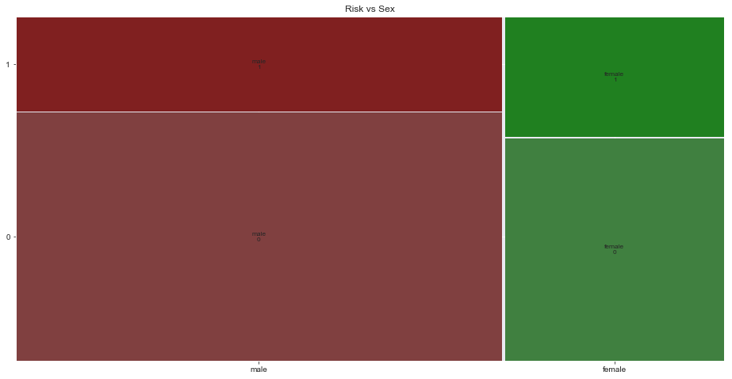

```python
mosaic(data[["Sex", "Risk"]], index=["Sex", "Risk"], title="Risk vs Sex")
```

```python
percentage_0_1("Sex")
```

```
-----------Out of all  male  ( 690 )-----------
27.68 %  male  -----------default
72.32 %  male  -----------not default

-----------Out of all  female  ( 310 )-----------
35.16 %  female  -----------default
64.84 %  female  -----------not default
```

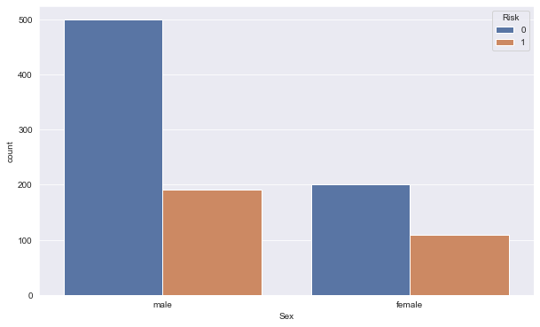

```python
sns.set({"figure.figsize": (10, 6)})
sns.countplot(data=data, x="Sex", hue="Risk")
```

- more chance to default-- female compare to males

### Risk vs Job

```python
pd.crosstab(index=data["Job"], columns=data["Risk"], rownames=[""])
```

| Risk | 0 | 1 |
| --- | --- | --- |
| highly skilled | 97 | 51 |
| skilled | 444 | 186 |
| unskilled_and_non-resident | 159 | 63 |

[output not shown]

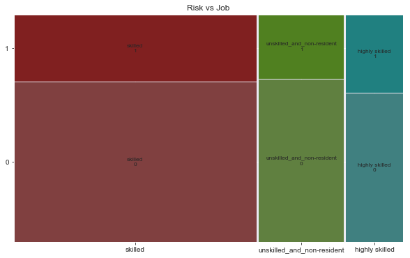

```python
mosaic(data[["Job", "Risk"]], index=["Job", "Risk"], title="Risk vs Job")
```

```python
percentage_0_1("Job")
```

```
-----------Out of all  skilled  ( 630 )-----------
29.52 %  skilled  -----------default
70.48 %  skilled  -----------not default

-----------Out of all  unskilled_and_non-resident  ( 222 )-----------
28.38 %  unskilled_and_non-resident  -----------default
71.62 %  unskilled_and_non-resident  -----------not default

-----------Out of all  highly skilled  ( 148 )-----------
34.46 %  highly skilled  -----------default
65.54 %  highly skilled  -----------not default
```

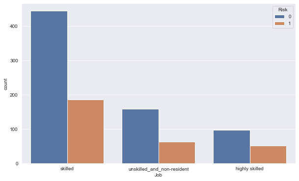

```python
sns.set({"figure.figsize": (10, 6)})
sns.countplot(data=data, x="Job", hue="Risk")
```

- more chances to default-- highly skilled compare to other categories but lessor in number

### Risk vs Housing

```python
pd.crosstab(index=data["Housing"], columns=data["Risk"], rownames=[""])
```

| Risk | 0 | 1 |
| --- | --- | --- |
| free | 64 | 44 |
| own | 527 | 186 |
| rent | 109 | 70 |

[output not shown]

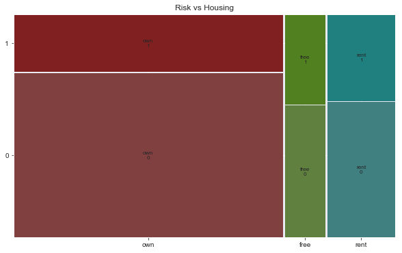

```python
mosaic(data[["Housing", "Risk"]], index=["Housing", "Risk"], title="Risk vs Housing")
```

```python
percentage_0_1("Housing")
```

```
-----------Out of all  own  ( 713 )-----------
26.09 %  own  -----------default
73.91 %  own  -----------not default

-----------Out of all  rent  ( 179 )-----------
39.11 %  rent  -----------default
60.89 %  rent  -----------not default

-----------Out of all  free  ( 108 )-----------
40.74 %  free  -----------default
59.26 %  free  -----------not default
```

- more chances to default-- persons who have rent/free housing

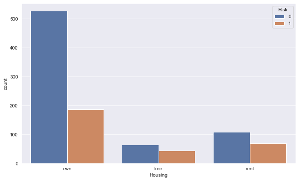

```python
sns.set({"figure.figsize": (10, 6)})
sns.countplot(data=data, x="Housing", hue="Risk")
```

### Risk vs Saving accounts

```python
pd.crosstab(index=data["Saving accounts"], columns=data["Risk"], rownames=[""])
```

| Risk | 0 | 1 |
| --- | --- | --- |
| little | 537 | 249 |
| moderate | 69 | 34 |
| quite rich | 52 | 11 |
| rich | 42 | 6 |

[output not shown]

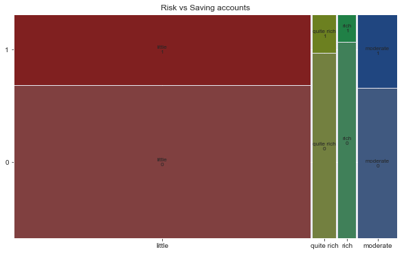

```python
mosaic(
    data[["Saving accounts", "Risk"]],
    index=["Saving accounts", "Risk"],
    title="Risk vs Saving accounts",
)
```

```python
percentage_0_1("Saving accounts")
```

```
-----------Out of all  little  ( 786 )-----------
31.68 %  little  -----------default
68.32 %  little  -----------not default

-----------Out of all  moderate  ( 103 )-----------
33.01 %  moderate  -----------default
66.99 %  moderate  -----------not default

-----------Out of all  quite rich  ( 63 )-----------
17.46 %  quite rich  -----------default
82.54 %  quite rich  -----------not default

-----------Out of all  rich  ( 48 )-----------
12.5 %  rich  -----------default
87.5 %  rich  -----------not default
```

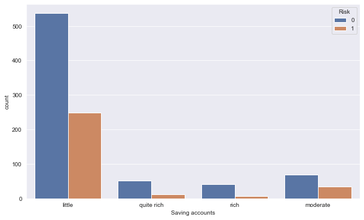

```python
sns.set({"figure.figsize": (10, 6)})
sns.countplot(data=data, x="Saving accounts", hue="Risk")
```

- less chances to default-- persons who have rich/quite-rich saving accounts but they are less in number
- more chances to default-- persons who have little/moderate saving accounts

### Risk vs Checking account

```python
pd.crosstab(index=data["Checking account"], columns=data["Risk"], rownames=[""])
```

| Risk | 0 | 1 |
| --- | --- | --- |
| little | 304 | 161 |
| moderate | 347 | 125 |
| rich | 49 | 14 |

[output not shown]

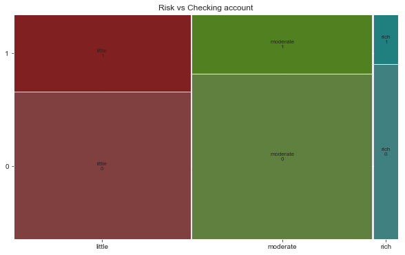

```python
mosaic(
    data[["Checking account", "Risk"]],
    index=["Checking account", "Risk"],
    title="Risk vs Checking account",
)
```

```python
percentage_0_1("Checking account")
```

```
-----------Out of all  moderate  ( 472 )-----------
26.48 %  moderate  -----------default
73.52 %  moderate  -----------not default

-----------Out of all  little  ( 465 )-----------
34.62 %  little  -----------default
65.38 %  little  -----------not default

-----------Out of all  rich  ( 63 )-----------
22.22 %  rich  -----------default
77.78 %  rich  -----------not default
```

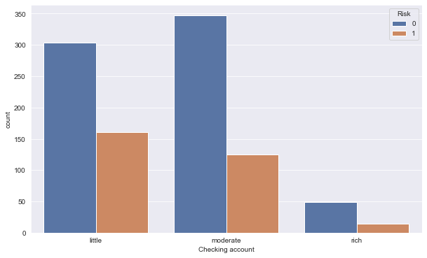

```python
sns.set({"figure.figsize": (10, 6)})
sns.countplot(data=data, x="Checking account", hue="Risk")
```

- more chances to default-- persons with little checking account

### Risk vs Purpose

```python
pd.crosstab(index=data["Purpose"], columns=data["Risk"], rownames=[""])
```

| Risk | 0 | 1 |
| --- | --- | --- |
| business | 63 | 34 |
| car | 231 | 106 |
| domestic appliances | 8 | 4 |
| education | 36 | 23 |
| furniture/equipment | 123 | 58 |
| radio/TV | 218 | 62 |
| repairs | 14 | 8 |
| vacation/others | 7 | 5 |

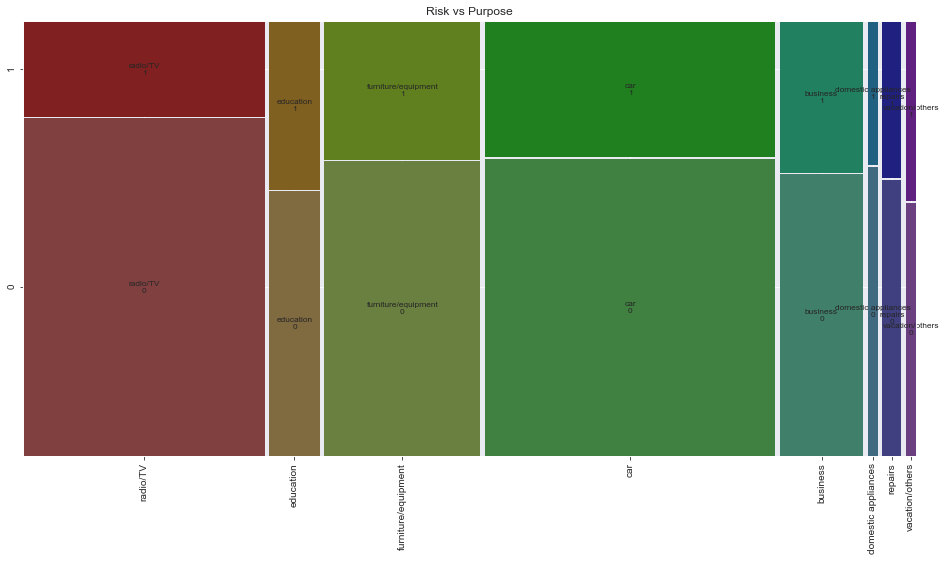

```python
sns.set({"figure.figsize": (16, 8)})
mosaic(
    data[["Purpose", "Risk"]], index=["Purpose", "Risk"], title="Risk vs Purpose",label_rotation=90
);
```

```python
percentage_0_1("Purpose")
```

```
-----------Out of all  car  ( 337 )-----------
31.45 %  car  -----------default
68.55 %  car  -----------not default

-----------Out of all  radio/TV  ( 280 )-----------
22.14 %  radio/TV  -----------default
77.86 %  radio/TV  -----------not default

-----------Out of all  furniture/equipment  ( 181 )-----------
32.04 %  furniture/equipment  -----------default
67.96 %  furniture/equipment  -----------not default

-----------Out of all  business  ( 97 )-----------
35.05 %  business  -----------default
64.95 %  business  -----------not default

-----------Out of all  education  ( 59 )-----------
38.98 %  education  -----------default
61.02 %  education  -----------not default

-----------Out of all  repairs  ( 22 )-----------
36.36 %  repairs  -----------default
63.64 %  repairs  -----------not default

-----------Out of all  domestic appliances  ( 12 )-----------
33.33 %  domestic appliances  -----------default
66.67 %  domestic appliances  -----------not default

-----------Out of all  vacation/others  ( 12 )-----------
41.67 %  vacation/others  -----------default
58.33 %  vacation/others  -----------not default
```

[output not shown]

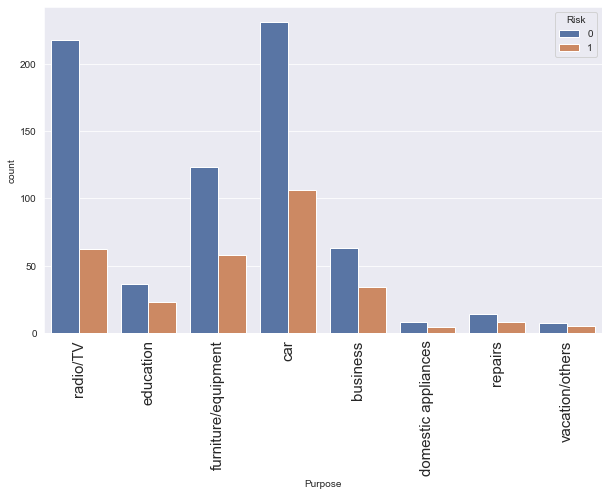

```python
sns.set({"figure.figsize": (10, 6)})
sns.countplot(data=data, x="Purpose", hue="Risk")
plt.xticks(rotation=90, fontsize=15)
```

- less chances to default-- persons who have taken credit for the purpose of radio/TV
- more chance to default-- persons who have taken credit for vacation-others, education, repairs compare to other categories

**Insights from bivariate analysis**

- more chances to default--younger customers compare to elder customers
- more chances to default--high credit amount compare to low credit amount customers
- more chances to default--high duration compare to customers having low duration
- more chance to default-- female compare to male customers
- more chances to default-- highly skilled compare to others
- more chances to default-- persons who have rent/free housing compare to others
- more chances to default-- persons who have little/moderate saving accounts compare to others
- more chances to default-- persons with little checking accountcompare to others
- more chance to default-- persons who have taken credit for vacation-others, education, repairs compare to other categories
- less chances to default-- persons who have rich/quite-rich saving accounts compare to others
- less chances to default-- persons who have taken credit for the purpose of radio/TV compare to others

## Multivariate Analysis

- to see the depth of insights from bivariate
- more interesting insights
- and can also explore the collinearity

```python
data2 = data.copy()
```

```python
data2["Risk"] = data2["Risk"].astype("object")  # data2 will have Risk as a object
```

```python
print("Continuous variables: ", data2.select_dtypes(exclude="object").columns.values)
print("Categorical variables: ", data2.select_dtypes(include="object").columns.values)
```

```
Continuous variables:  ['Age' 'Credit amount' 'Duration']
Categorical variables:  ['Sex' 'Job' 'Housing' 'Saving accounts' 'Checking account' 'Risk'
 'Purpose']
```

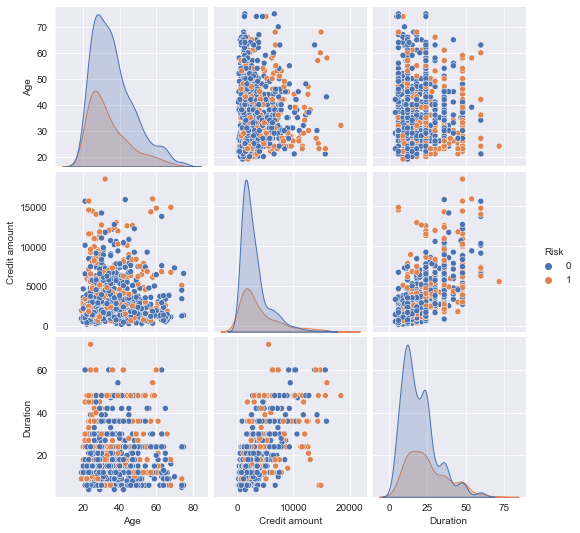

```python
sns.pairplot(data2, hue="Risk")
```

- There are overlaps i.e., no clear distinction in the distribution of variables for people who have defaulted and did not default.

### Job vs purpose vs Risk

[output not shown]

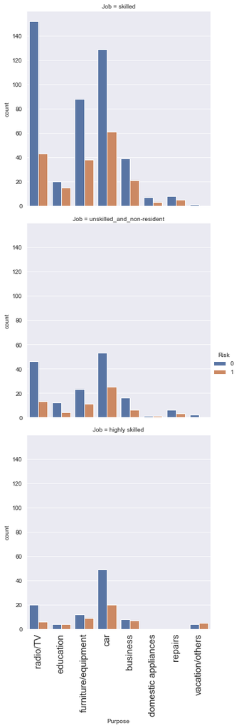

```python
sns.catplot(data=data2, x="Purpose", row="Job", hue="Risk", kind="count")
plt.xticks(rotation=90, fontsize=15)
```

```python
df1 = pd.crosstab(index=[data2["Job"], data2["Purpose"]], columns=data2["Risk"],)
df1
```

| Job | Risk Purpose | 0 | 1 |
| --- | --- | --- | --- |
| highly skilled | business | 8 | 7 |
|  | car | 49 | 20 |
|  | education | 4 | 4 |
|  | furniture/equipment | 12 | 9 |
|  | radio/TV | 20 | 6 |
|  | vacation/others | 4 | 5 |
| skilled | business | 39 | 21 |
|  | car | 129 | 61 |
|  | domestic appliances | 7 | 3 |
|  | education | 20 | 15 |
|  | furniture/equipment | 88 | 38 |
|  | radio/TV | 152 | 43 |
|  | repairs | 8 | 5 |
|  | vacation/others | 1 | 0 |
| unskilled_and_non-resident | business | 16 | 6 |
|  | car | 53 | 25 |
|  | domestic appliances | 1 | 1 |
|  | education | 12 | 4 |
|  | furniture/equipment | 23 | 11 |
|  | radio/TV | 46 | 13 |
|  | repairs | 6 | 3 |
|  | vacation/others | 2 | 0 |

```python
df1["not_default(%)"] = np.round((df1[0] / (df1[0] + df1[1])) * 100, 2)
df1["default(%)"] = np.round((df1[1] / (df1[0] + df1[1])) * 100, 2)
df1
```

| Job | Risk Purpose | 0 | 1 | not_default(%) | default(%) |
| --- | --- | --- | --- | --- | --- |
| highly skilled | business | 8 | 7 | 53.33 | 46.67 |
|  | car | 49 | 20 | 71.01 | 28.99 |
|  | education | 4 | 4 | 50.00 | 50.00 |
|  | furniture/equipment | 12 | 9 | 57.14 | 42.86 |
|  | radio/TV | 20 | 6 | 76.92 | 23.08 |
|  | vacation/others | 4 | 5 | 44.44 | 55.56 |
| skilled | business | 39 | 21 | 65.00 | 35.00 |
|  | car | 129 | 61 | 67.89 | 32.11 |
|  | domestic appliances | 7 | 3 | 70.00 | 30.00 |
|  | education | 20 | 15 | 57.14 | 42.86 |
|  | furniture/equipment | 88 | 38 | 69.84 | 30.16 |
|  | radio/TV | 152 | 43 | 77.95 | 22.05 |
|  | repairs | 8 | 5 | 61.54 | 38.46 |
|  | vacation/others | 1 | 0 | 100.00 | 0.00 |
| unskilled_and_non-resident | business | 16 | 6 | 72.73 | 27.27 |
|  | car | 53 | 25 | 67.95 | 32.05 |
|  | domestic appliances | 1 | 1 | 50.00 | 50.00 |
|  | education | 12 | 4 | 75.00 | 25.00 |
|  | furniture/equipment | 23 | 11 | 67.65 | 32.35 |
|  | radio/TV | 46 | 13 | 77.97 | 22.03 |
|  | repairs | 6 | 3 | 66.67 | 33.33 |
|  | vacation/others | 2 | 0 | 100.00 | 0.00 |

- most chance to default-- person with high skill and purpose vacation/others

### Saving accounts vs Checking accounts vs Risk

```python
pd.crosstab(index=data2["Saving accounts"], columns=data2["Checking account"])
```

| Checking account Saving accounts | little | moderate | rich |
| --- | --- | --- | --- |
| little | 439 | 296 | 51 |
| moderate | 12 | 86 | 5 |
| quite rich | 8 | 51 | 4 |
| rich | 6 | 39 | 3 |

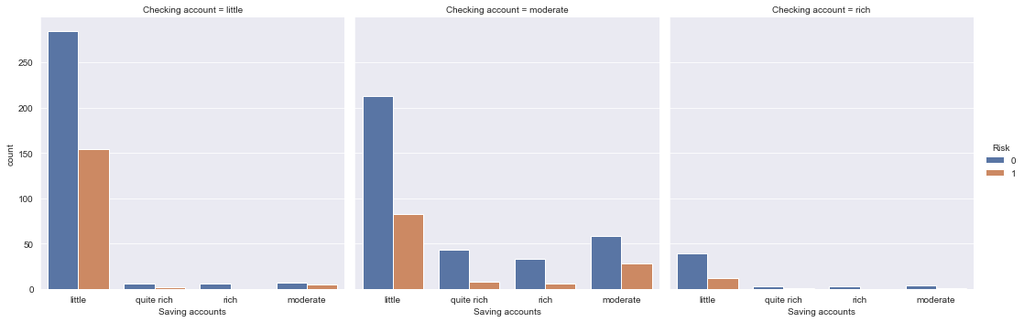

```python
sns.catplot(
    data=data2, x="Saving accounts", col="Checking account", hue="Risk", kind="count"
)
```

```python
df2 = pd.crosstab(
    index=[data2["Checking account"], data2["Saving accounts"]], columns=data2["Risk"]
)
df2
```

| Checking account | Risk Saving accounts | 0 | 1 |
| --- | --- | --- | --- |
| little | little | 285 | 154 |
|  | moderate | 7 | 5 |
|  | quite rich | 6 | 2 |
|  | rich | 6 | 0 |
| moderate | little | 213 | 83 |
|  | moderate | 58 | 28 |
|  | quite rich | 43 | 8 |
|  | rich | 33 | 6 |
| rich | little | 39 | 12 |
|  | moderate | 4 | 1 |
|  | quite rich | 3 | 1 |
|  | rich | 3 | 0 |

```python
df2["not_default(%)"] = np.round((df2[0] / (df2[0] + df2[1])) * 100, 2)
df2["default(%)"] = np.round((df2[1] / (df2[0] + df2[1])) * 100, 2)
df2
```

| Checking account | Risk Saving accounts | 0 | 1 | not_default(%) | default(%) |
| --- | --- | --- | --- | --- | --- |
| little | little | 285 | 154 | 64.92 | 35.08 |
|  | moderate | 7 | 5 | 58.33 | 41.67 |
|  | quite rich | 6 | 2 | 75.00 | 25.00 |
|  | rich | 6 | 0 | 100.00 | 0.00 |
| moderate | little | 213 | 83 | 71.96 | 28.04 |
|  | moderate | 58 | 28 | 67.44 | 32.56 |
|  | quite rich | 43 | 8 | 84.31 | 15.69 |
|  | rich | 33 | 6 | 84.62 | 15.38 |
| rich | little | 39 | 12 | 76.47 | 23.53 |
|  | moderate | 4 | 1 | 80.00 | 20.00 |
|  | quite rich | 3 | 1 | 75.00 | 25.00 |
|  | rich | 3 | 0 | 100.00 | 0.00 |

- least chances to default-- person having rich checking account and any saving account except little
- least chances to default-- person having little checking account and rich/quite-rich saving account
- more chances to default-- person having little checking account and moderate saving account compare to person with other saving accounts

### Housing vs saving accounts vs check accounts vs risk

- whole dataset has 71% own house, 18% rented house, 11% free housing
- more chances to default-- persons who have rent/free housing compare to others

```python
pd.crosstab(index=data2["Saving accounts"], columns=data2["Housing"])
```

| Housing Saving accounts | free | own | rent |
| --- | --- | --- | --- |
| little | 90 | 560 | 136 |
| moderate | 10 | 71 | 22 |
| quite rich | 6 | 45 | 12 |
| rich | 2 | 37 | 9 |

```python
pd.crosstab(index=data2["Checking account"], columns=data2["Housing"])
```

| Housing Checking account | free | own | rent |
| --- | --- | --- | --- |
| little | 53 | 324 | 88 |
| moderate | 47 | 342 | 83 |
| rich | 8 | 47 | 8 |

- no such a influence of saving accounts/checking accounts on the housing

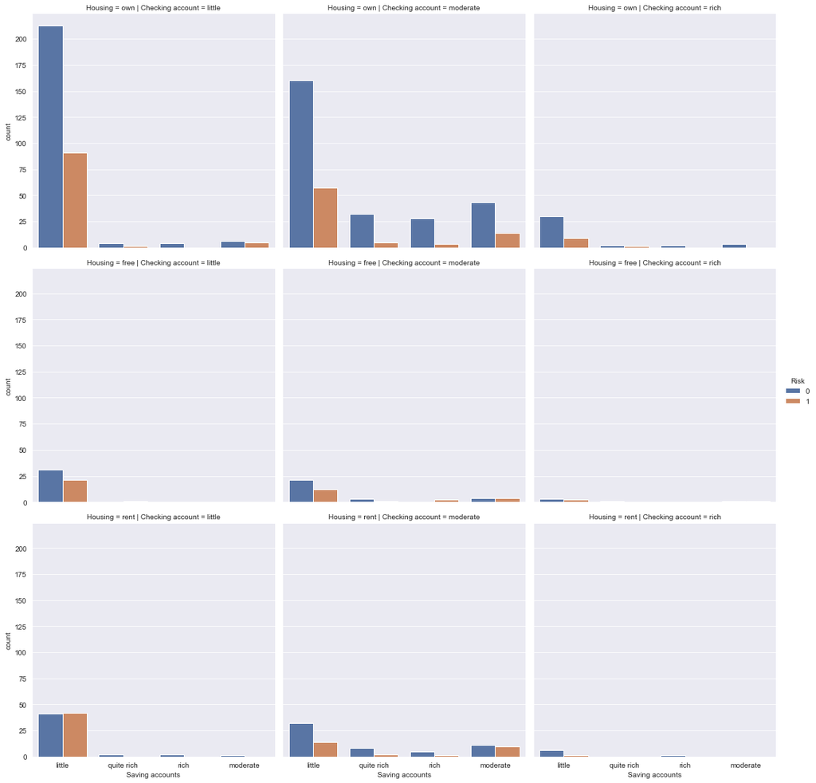

```python
sns.catplot(
    data=data2,
    x="Saving accounts",
    col="Checking account",
    row="Housing",
    hue="Risk",
    kind="count",
)
```

```python
df3 = pd.crosstab(
    index=[data2["Housing"], data2["Checking account"], data2["Saving accounts"]],
    columns=data2["Risk"],
)
df3
```

| Housing | Checking account | Risk Saving accounts | 0 | 1 |
| --- | --- | --- | --- | --- |
| free | little | little | 31 | 21 |
|  |  | quite rich | 0 | 1 |
|  | moderate | little | 21 | 12 |
|  |  | moderate | 4 | 4 |
|  |  | quite rich | 3 | 1 |
|  |  | rich | 0 | 2 |
|  | rich | little | 3 | 2 |
|  |  | moderate | 1 | 1 |
|  |  | quite rich | 1 | 0 |
| own | little | little | 213 | 91 |
|  |  | moderate | 6 | 5 |
|  |  | quite rich | 4 | 1 |
|  |  | rich | 4 | 0 |
|  | moderate | little | 160 | 57 |
|  |  | moderate | 43 | 14 |
|  |  | quite rich | 32 | 5 |
|  |  | rich | 28 | 3 |
|  | rich | little | 30 | 9 |
|  |  | moderate | 3 | 0 |
|  |  | quite rich | 2 | 1 |
|  |  | rich | 2 | 0 |
| rent | little | little | 41 | 42 |
|  |  | moderate | 1 | 0 |
|  |  | quite rich | 2 | 0 |
|  |  | rich | 2 | 0 |
|  | moderate | little | 32 | 14 |
|  |  | moderate | 11 | 10 |
|  |  | quite rich | 8 | 2 |
|  |  | rich | 5 | 1 |
|  | rich | little | 6 | 1 |
|  |  | rich | 1 | 0 |

- less chance to default--samples having housing=rent, checking account=little and saving account!=little. i.e., 5 samples belong to that combination and all having risk=0

```python
df3[(df3[0] == 0) | (df3[1] == 0)]
```

| Housing | Checking account | Risk Saving accounts | 0 | 1 |
| --- | --- | --- | --- | --- |
| free | little | quite rich | 0 | 1 |
|  | moderate | rich | 0 | 2 |
|  | rich | quite rich | 1 | 0 |
| own | little | rich | 4 | 0 |
|  | rich | moderate | 3 | 0 |
|  |  | rich | 2 | 0 |
| rent | little | moderate | 1 | 0 |
|  |  | quite rich | 2 | 0 |
|  |  | rich | 2 | 0 |
|  | rich | rich | 1 | 0 |

- least chance to default-- persons who own the house and have checking account little and saving account rich i.e., there are total 4 samples in the dataset that have own+little+rich and all have risk=0
- although there are lot of zeros but very few samples belong to these combinations. i.e., samples having free+moderate+rich attributes all belong to risk=1(default). But there are just 2 samples evidencing this combination